# Analyse descriptive du mix cultural de la Bretagne (2007-2023)

Aziliz Joseph dit Pagny, Inès Bezie et Loïc Henry

2025-06-12

## Introduction

Ce document présente la répartition des cultures en Bretagne à partir des données du **Registre Parcellaire Graphique** (RPG). Le RPG est une base de données géographique qui recense les parcelles agricoles et les cultures qui y sont pratiquées. Ces données sont déclarées par les agriculteurs dans le cadre de leur déclaration de la Politique Agricole Commune. Elles sont en [libre accès](https://geoservices.ign.fr/rpg) et sont mises à jour chaque année.

L’objectif de cette analyse est de visualiser la diversité des cultures pratiquées en Bretagne et d’identifier les principales cultures présentes dans la région. En particulier, nous souhaitons identifier les dynamiques des cultures (cultures émergentes ou en déclin) ainsi que leur répartition spatiale. Cette analyse utilise les données du RPG sur 17 années (2007-2023), aggrégées à l’échelle de la commune. Les scripts permettant de collecter, et préparer les données du RPG sont disponibles sur GitHub dans le dépôts [`RPG_PrepareData`](https://github.com/loichy/RPG_PrepareData) Nous disposons ainsi de l’usage des sols entre 24 et 28 grands groupes de culture. Nous mesurons la surface dédié à chaque groupe de culture par commune et année, ainsi que le nombre de parcelles.

Dans une première partie, nous présentons l’usage des sols de manière globale en Bretagne sur la période 2007-2023. Dans la deuxième section, nous étudions la dynamique des usages des sols, en étudiant en particulier l’expansion des cultures émergentes et le déclin des cultures en perte de vitesse. Enfin, nous étudions la diversité des cultures à l’échelle des communes et son évolution dans le temps.

## Le mix cultural en Bretagne: une présentation générale

### Evolution de la surface agricole en Bretagne

Le graphique ci-dessous montre l’évolution sur la période 2007-2023 de la surface agricole totale en Bretagne ainsi que sa distribution entre communes.

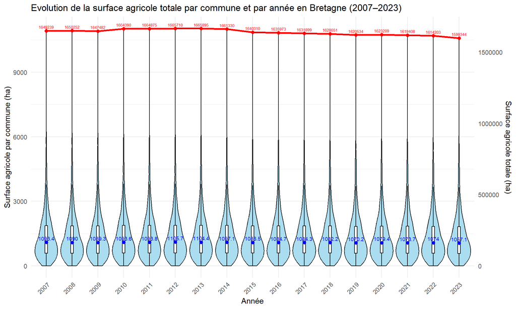

Ce graphique montre que la surface agricole utilisée totale en Bretagne reste relativement stable dans le temps (ligne rouge). De manière générale, on observe une légère décroissance de la surface agricole totale, qui a diminué de près de 4% entre 2013 et 2023.

La distribution de la surface agricole totale par commune montre également une stabilité importante (graphiques en violon, et boite à moustache associée). Près de 90% des communes en Bretagne ont une surface agricole utilisée inférieures à 3000 ha, et la médiane de la surface agricole utilisée des communes restent stable dans le temps (environ 1 080 ha).

A noter qu’en agriculture on parle davantage en hectares qu’en mètres carrés. *1 hectare = 10 000 mètres carrés donc 30 000 000 mètres carrés = 3000 hectares.

### La spécialisation des cultures en Bretagne

#### Surface agricole par culture

La tableau ci-dessous présente les surfaces agricoles utilisés par culture en Bretagne sur la période 2007-2023. Il s’agit du total des surfaces par culture sur toutes les parcelles, qui est calculé par année et dont nous présentons ici la moyenne sur la période 2007-2023.

Utilisation des sols agricoles par culture (moyenne sur la période 2007–2023)

| Groupe de culture | Surface de la culture (ha) | Part (%) |
| --- | --- | --- |
| Surface agricole totale | 1664111.3 | NA |
| Maïs grain et ensilage | 447515.7 | 27.3 |
| Prairies temporaires | 398230.1 | 24.2 |
| Blé tendre | 296648.3 | 18.1 |
| Prairies permanentes | 186632.3 | 11.4 |
| Orge | 86933.7 | 5.3 |
| Autres céréales | 61235.5 | 3.7 |
| Légumes ou fleurs | 52898.3 | 3.2 |
| Colza | 45495.1 | 2.8 |
| Fourrage | 28985.2 | 1.8 |
| Divers | 16037.6 | 1.0 |
| Protéagineux | 12200.5 | 0.7 |
| Gel (surfaces gelées sans production) | 12094.8 | 0.7 |
| Estives et landes | 4046.0 | 0.2 |
| Autres cultures industrielles | 4026.9 | 0.2 |
| Vergers | 2973.0 | 0.2 |
| Autres oléagineux | 2883.0 | 0.2 |
| Tournesol | 2769.1 | 0.2 |
| Plantes à fibres | 1887.6 | 0.1 |
| Légumineuses à grains | 313.5 | 0.0 |
| Fruits à coque | 238.5 | 0.0 |
| Vignes | 61.8 | 0.0 |
| Oliviers | 2.8 | 0.0 |
| Riz | 1.9 | 0.0 |

*Note : Les surfaces sont exprimées en hectares (ha) ; les parts correspondent à la proportion de chaque culture par rapport à la surface agricole totale.*

La surface agricole totale est de 1.6641113^{6} ha. Notons que le [recensement agricole de 2020](https://draaf.bretagne.agriculture.gouv.fr/agreste-etudes-no4-2021-recensement-agricole-2020-la-bretagne-perd-un-quart-de-a2611.html) reporte une surface agricole totale de 1 624 200 ha, soit une surface 2.46 % plus petite.

#### Part de parcelles agricoles par culture

La figure ci-dessous représente le pourcentage de parcelles agricoles par type de culture en Bretagne pour quatre années (2007, 2012, 2017 et 2023). Il s’agit du nombre de parcelles par culture divisé par le nombre total de parcelles recensés par le RPG en Bretagne sur l’année.

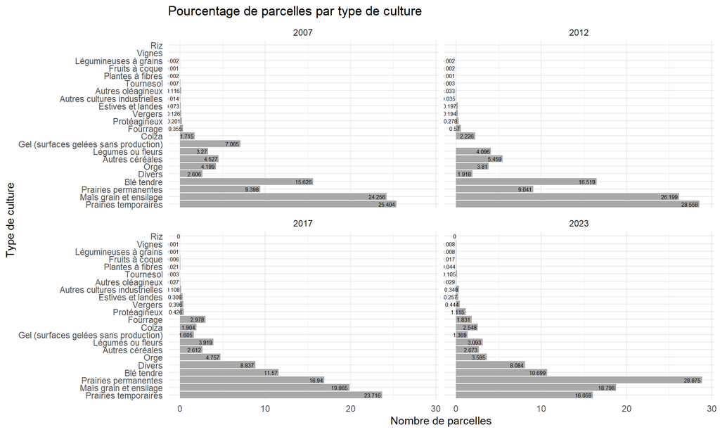

Cependant, des cultures moins visibles dans la surface agricole totale paraissent comme plus présentent en pourcentage de parcelles. Il s’agit de culture cultivée souvent sur des plus petites parcelles, telles que les légumes ou fleurs, et les cultures divers. Si celles-ci représentent respectivement 3.2% et 1% de la surface agricole totale, elles représentent 3.9% et 8.9% des parcelles cultivées en Bretagne en 2017.

## Evolution dynamique du mix cultural en Bretagne

Cette section présente des analyses statistiques visant à identifier des cultures en développement et en déclin en Bretagne. Etant donné le grand nombre de catégorie de cultures différentes, et la très grande domination de la surface agricole pour certaines de ces cultures la comparaison directe de l’évolution des surfaces n’ait pas rendue facile. Certaines cultures ont des surfaces très largement supérieur, par exemple la culture de maïs est environ 1 000 fois plus importante en surface que la culture des légumineuses. Le graphique ci-dessous présente l’évolution des parts de surfaces agricoles utilisées par culture en Bretagne sur la période 2007-2023. Nous voyons qu’il est délicat d’identifier les dynamiques de toutes les cultures à partir de ce graphique, étant donné les différences d’importance/d’échelle entre elles.

[interactive chart not shown]

Nous remarquons ici que la part des surfaces en prairie permanente a plus que triplé entre 2014 et 2018, passant de 5,9% à 20%, tandis que celle de la prairie temporaire a été divisé part deux, passant de 30,3% à 14,7%. La diminution des surfaces en prairies temporaires peut s’expliquer en partie par une requalification de ces surfaces en prairies permanentes. En dehors d’une variation importante de la part des surfaces associées aux prairies, il est délicat d’identifier d’autres dynamiques pour les autres cultures sur ce graphique.

Pour cette raison, nous avons choisi de présenter les évolutions relatives des surfaces agricoles par culture. Dans un premier temps, nous calculons alors le taux de croissance inter-annuel des surfaces agricoles utilisés par la culture, de la manière suivante $g_{kt} = \dfrac{y_{kt} - y_{kt-1}}{y_{kt-1}}$, où $g_{kt}$ est le taux de croissance de la culture $k$ à l’année $t$, et $y_{kt}$ est la surface agricole utilisée par la culture $k$ à l’année $t$. Cette analyse permet de comprendre la variabilité entre année des surfaces utilisés par la culture.

Dans un second temps, nous calculons la croissance de la surface associé à la culture en base 100, où l’année de référence est celle associée à l’entrée de la culture dans les données RPG. Ainsi, pour chaque culture, nous calculons la surface agricole utilisée par la culture $k$ à l’année $t$ divisé par la surface agricole utilisée par la culture $k$ à l’année d’entrée dans les données RPG, que nous multiplions par 100. Cette analyse permet de comprendre l’évolution des surfaces agricoles utilisées par la culture depuis son entrée dans les données RPG, et de comparer alors les croissances des surfaces entre culture.

### Analyse des taux de croissance inter-annuels des surfaces agricoles

Le tableau ci-dessous présente le nombre d’années de données ou chaque culture apparaît dans notre échantillon, ainsi que le taux de croissance annuel moyen des surfaces agricoles utilisées par culture sur la période 2007-2023.

Taux de croissance annuel moyen des surfaces agricoles par culture sur la période 2007–2023

| Groupe de culture | Nombre d’années | Taux de croissance annuel moyen |
| --- | --- | --- |
| Vignes | 9 | 955.4878819 [1] |
| Riz | 9 | 113.3323345 [1] |
| Plantes à fibres | 16 | 111.9261494 [1] |
| Légumineuses à grains | 14 | 58.1304307 [1] |
| Tournesol | 17 | 53.1630635 [1] |
| Fruits à coque | 17 | 38.2078853 [1] |
| Autres cultures industrielles | 17 | 37.7294665 [1] |
| Protéagineux | 17 | 35.7526624 [1] |
| Fourrage | 17 | 34.0840932 [1] |
| Prairies permanentes | 17 | 9.3235933 [1] |
| Vergers | 17 | 6.5556444 [1] |
| Colza | 17 | 6.3355395 [1] |
| Estives et landes | 17 | 6.1753243 [1] |
| Autres oléagineux | 17 | 5.2600565 [1] |
| Orge | 17 | 2.3328859 [1] |
| Blé tendre | 17 | 0.6290358 [1] |
| Maïs grain et ensilage | 17 | 0.3338785 [1] |
| Divers | 17 | -0.4492808 [1] |
| Autres céréales | 17 | -0.5962302 [1] |
| Légumes ou fleurs | 17 | -0.9786653 [1] |
| Prairies temporaires | 17 | -4.3299469 [1] |
| Gel (surfaces gelées sans production) | 12 | -11.7830703 [1] |
| Oliviers | 1 | NaN [1] |

On remarque une très forte expansion de la vigne, qui chaque année depuis qu’elle est cultivée en Bretagne (2014) voit sa surface se multiplier par 10,5 en moyenne. Le riz et les plantes à fibre sont également des cultures en forte expansion, avec un taux de croissance annuel moyen de 113% et 111% respectivement, signifie que leur surface fait plus que doubler chaque année. A l’inverse, les cultures en déclin sont les prairies temporaires, qui ont vu leur surface diminuer de 4,3% par an en moyenne depuis 2007, ainsi que les légumes et fleurs (-1%) et les surfaces gelées (-11.7%). Les résultats de ce tableau sont également représentés dans le figures suivantes, pour la croissance moyenne des surfaces et la croissance moyenne des parcelles:

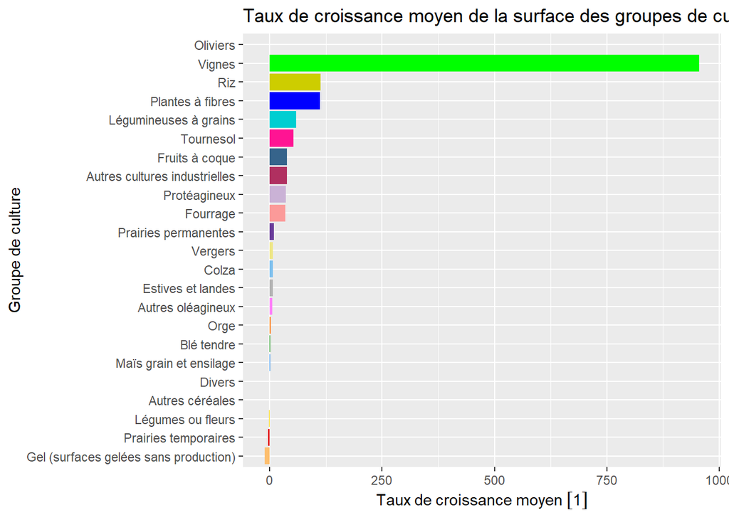

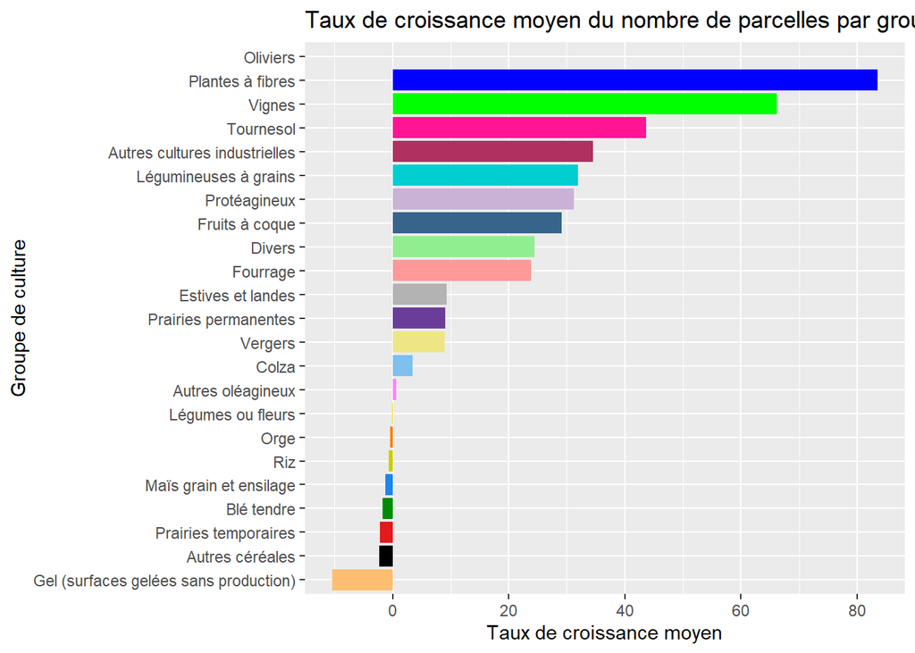

Si nous nous attachons à présent au taux de croissance moyen en termes de nombre de parcelles cultivées, nous constatons que le riz n’est plus une culture avec une tendance dominante à la croissance en termes de l’expansion en nombre de parcelles cultivées. Viennent alors à se détacher principalement les plantes à fibres et les vignes.

La non prégnance du riz sur le second graphique (en termes de parcelles cultivées) vient confirmer l’idée que le riz reste une culture minoritaire, qui se concentrent sur un nombre limité de parcelles et qui ne vient pas exploser même si sur le premier graphique elle semble dominante de par sa tendance générale à une croissance en termes de surface cultivée au cours du temps. A l’inverse, il semble qu’il y ait un véritable intérêt pour les plantes à fibre dont la culture tend en moyenne à croître tant en termes de surface cultivée (considérablement) et que de nombre de parcelles.

Plus précisément, il serait intéressant de voir où le riz et les oliviers ont été implantés en Bretagne, et de quelle manière sont tirés ces taux de croissance. Le tableau suivant présente les implantations des cultures du riz, des oliviers et de la vigne en Bretagne depuis 2010, ainsi que le nombre de communes dans lesquelles elles sont cultivées et la surface totale cultivée par culture.

Implantations des cultures du riz, des oliviers et de la vigne en Bretagne (2010–2023)

| Groupe de culture | Année | Nombre de communes d’implantation | Surface (ha) |
| --- | --- | --- | --- |
| Oliviers | 2010 | 2 | 2.81490232 [m^2] |
| Riz | 2015 | 1 | 0.16641442 [m^2] |
| Riz | 2016 | 1 | 0.16641442 [m^2] |
| Riz | 2017 | 1 | 0.16641442 [m^2] |
| Riz | 2018 | 1 | 1.80835200 [m^2] |
| Riz | 2019 | 1 | 0.04765220 [m^2] |
| Riz | 2020 | 1 | 0.07026375 [m^2] |
| Riz | 2021 | 1 | 0.07026375 [m^2] |
| Riz | 2022 | 1 | 0.07026375 [m^2] |
| Riz | 2023 | 1 | 0.04654961 [m^2] |
| Vignes | 2014 | 1 | 4.30380091 [m^2] |
| Vignes | 2016 | 2 | 0.28497761 [m^2] |
| Vignes | 2017 | 1 | 0.01362971 [m^2] |
| Vignes | 2018 | 4 | 0.63433072 [m^2] |
| Vignes | 2019 | 6 | 1.93506051 [m^2] |
| Vignes | 2020 | 4 | 0.52260697 [m^2] |
| Vignes | 2021 | 11 | 15.87638665 [m^2] |
| Vignes | 2022 | 19 | 31.67012166 [m^2] |
| Vignes | 2023 | 44 | 59.69315978 [m^2] |

La représentation graphique ci-dessous montre l’évolution des taux de croissances annuels à partir d’une échelle en couleur.

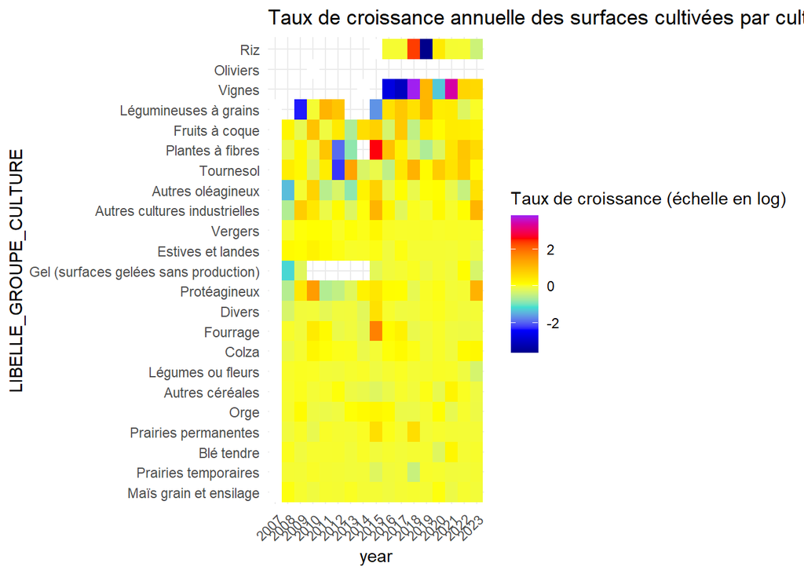

On remarque que les taux de croissance interannuels sont relativement proches pour un grand nombre de culture, et varie peu entre les année. Cette représentation a l’avantage d’identifier rapidement les cultures qui représentent une forte instabilité sur la période comme le riz, les vignes, les légumineuses, les plantes à fibre, les fruits à coques, les tournesols et les autres oléagineux.

Enfin, le graphique ci-dessous montre l’évolution du taux de croissance inter-annuel par culture sur la période 2007-2023.

[interactive chart not shown]

Ce graphique illustre la relative variabilité dans l’utilisation des sols agricoles, avec des variations assez importantes d’une année à l’autre pour certaines cultures. Les courbes se chevauchant autour de 0 pour les cultures les plus stables, il est plus aisé de s’attacher aux cultures qui ont tendance à fluctuer au fil des années.

Trois cultures ont majoritairement les variations les plus importantes, entre croissance et décroissance, c’est-à-dire entre augmentation de la surface cultivée et diminution, marquées donc par une forme d’instabilité: les légumineuses à grains (courbe bleue claire), le tournesol (courbe fuschia) et les plantes à fibres (courbe bleu). On remarque également une forte variation du taux de croissance du fourage sur une année seulement.

Finalement, notons également l’explosion des autres cultures industrielles et des protéagineux en 2023, dont la surface agricole cultivée augmente de plus de 200%.

### Analyse de croissance des surfaces agricoles utilisés selon les groupes de cultures à partir de leur année d’implantation (année de référence)

Nous optons ici pour une division du groupe en deux “échantillons”. En effet, les données dont nous disposons sont issues de deux types de recensement parcellaire : un recensement selon la catégorisation d’îlots anonymes (regroupement d’ensemble de cultures et de parcelles en de plus grands groupes), qui prend fin en 2015 pour laisser place à une catégorisation en parcelles graphiques (analyse plus fine).

Il s’agit alors d’étudier d’un côté la période 2007-2014 et de l’autre celle 2015-2023, le but étant de se détacher du biais créé par la méthode de recensement des données. D’autre part, une analyse à partir d’une année de référence permet de visualiser la tendance des cultures sur le long terme (explosion, disparition …).

### Analyse ciblée : les 10 groupes de culture qui la croissance moyenne la plus élevé (en termes de surfaces cultivées)

[interactive chart not shown]

A partir de 2012, les fruits à coque sont un groupe de culture qui tend à croître jusqu’en 2015, avec un triplement de sa surface par rapport à 2007 (année d’implantation). D’autre part, sur la première sous-période (2012-2015), on constate également une décroissance de certains groupes de cultures comme les légumineuses ou le tournesol.

Finalement, de manière plus marginale, si nous étudions le cas particulier du riz: implanté en 2015, sa surface agricole cultivé croît de manière importante en 2018 (+987%) mais ne continuera pas sur cette voie, accusant des taux de croissance négatifs dès 2019 et jusque 2023 (entre -58% et -72% par rapport à 2015).

### Analyse ciblée : les 10 groupes de culture qui ont la croissance moyenne la plus faible (en termes de surfaces cultivées)

[interactive chart not shown]

Les autres olégaineux sont le groupe de culture principalement en baisse sur la première sous-période (2007-2014) alors qu’on constate une stabilisation des surfaces cultivées sur la seconde période (2015-2023). Les prairies temporaires sont également un groupe de culture qui subit une baisse continue et progressive de sa surface agricole cultivée en Bretagne. D’autres cultures restent relativement stables voire en légère croissance au cours de la période étudiée comme les autres céréales, les légumes ou fleurs ou encore le maïs grain et ensilage. Un constat qui peut-être fait grâce à cette visualisation ciblée sur les 10 cultures au taux de croissance moyen le plus faible et qui est plus difficile à percevoir sur une visualisation englobant l’ensemble des groupes de cultures cultivés en Bretagne.

### Analyse de l’hétérogénéité de la croissance des surfaces de culture de 2019 à 2023

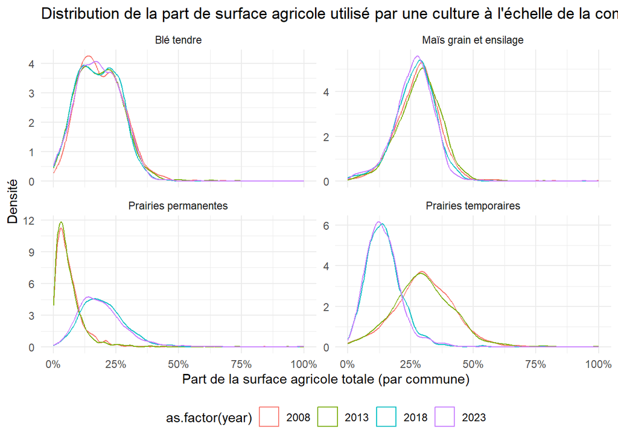

```r
select_annees <- c(2008, 2013, 2018, 2023)
select_cultures <- c("Maïs grain et ensilage", "Prairies permanentes", "Prairies temporaires", "Blé tendre")

density_commune <- RPG_R53 |>
  filter(year %in% select_annees,
         LIBELLE_GROUPE_CULTURE %in% select_cultures)

ggplot(density_commune, aes(x = as.numeric(surf_code_group_perc),  color = as.factor(year))) +
  geom_density(size = 0.5) +
  facet_wrap(~ LIBELLE_GROUPE_CULTURE, scales = "free_y") +
  scale_x_continuous(labels = scales::percent_format(accuracy = 1)) +
  labs(
    title = "Distribution de la part de surface agricole utilisé par une culture à l'échelle de la commune par année",
    x = "Part de la surface agricole totale (par commune)",
    y = "Densité"
  ) +
  theme_minimal() +
  theme(legend.position = "bottom")
```

```r
ggsave(here(dir$output, "densite_culture.pdf"), width = 16, height = 10)
```

Pour le blé tendre et le maïs grain/ensilage, les distributions sont particulièrement stables sur les quatre années. La densité est concentrée autour de 10 à 30 %, avec peu de variations. Cela suggère que ces cultures, bien qu’importantes, occupent rarement une position dominante au sein des communes agricoles.

En revanche, les prairies permanentes présentent une évolution nette en 2018 : la courbe se déplace vers la droite, indiquant une augmentation du nombre de communes dont une part importante est consacrée à ce type de surface.

Cette inflexion s’explique très probablement par la réforme de la PAC intervenue en fin d’année 2017, dite “Règlement Omnibus”, et appliquée à partir de la campagne 2018. Cette réforme a élargi la définition des prairies permanentes, en autorisant l’inclusion de prairies pastorales à dominante ligneuse, traditionnellement exploitées pour le pâturage, même si l’herbe n’y est pas majoritaire. En France, cette évolution a été adoptée dès 2018 et a concerné 38 départements, dont 15 nouvellement éligibles. Elle a eu pour effet direct d’augmenter les surfaces déclarables en prairies permanentes, entraînant une hausse visible dans les déclarations communales.

De plus, dans certaines régions (notamment les Hauts-de-France et la Normandie), des régimes d’interdiction ou d’autorisation préalable de conversion de prairies ont été instaurés à la suite d’une dégradation excessive du ratio de maintien des prairies. Cela a sans doute incité les exploitants à maintenir voire réaffecter davantage de surfaces en prairie permanente dans leurs déclarations.

Concernant les prairies temporaires, une autre évolution apparaît en 2018, sous la forme d’une courbe de densité plus étroite, centrée autour de 12,5%. Cela suggère une plus faible variabilité dans les surfaces dédiées au prairie temporaires entre communes. Cela pourrait possiblement s’expliquer par une forme de standardisation ou d’harmonisation dans les pratiques déclaratives, possiblement en lien avec la clarification des règles de distinction entre prairies permanentes et temporaires induite par la réforme.

## Analyse de la diversité culturale par commune

### Evolution moyenne du nombre de culture différentes

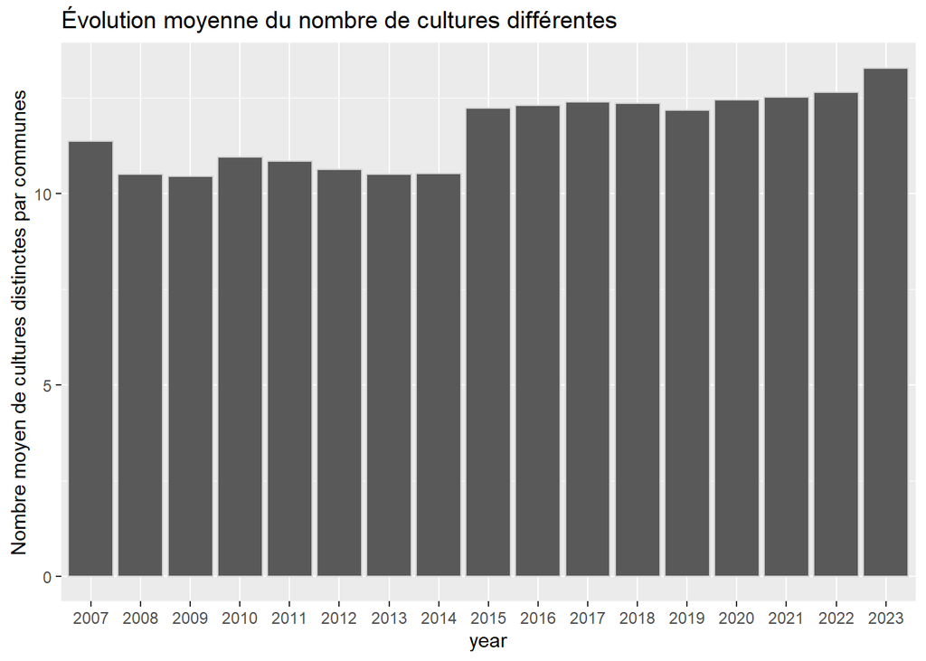

```r
RPG_R53 %>%
  group_by(year, name) %>%
  summarise(N_Cultures = n_distinct(LIBELLE_GROUPE_CULTURE), .groups = "drop") %>%
  group_by(year) %>%
  summarise(moyenne_cultures = mean(N_Cultures)) %>%
  ggplot(aes(x = year, y = moyenne_cultures)) +
  geom_col(colour = "lightgrey") +
  labs(title = "Évolution moyenne du nombre de cultures différentes", y = "Nombre moyen de cultures distinctes par communes")
```

### Indice de Shannon par commune et par année

```r
#|echo: false
#|message: false
#|warning: false
```

[output not shown]

L’indice de Shannon, indicateur issu de l’écologie et que l’on chercher à appliquer ici à l’agriculture, mesure la diversité culturale moyenne dans la région entre 2007 et 2023.

Plus il est élevé, plus la diversité des cultures est importante.

*Nb : définition de l’indice de Shanon :* *H = -Σp(i)xln(p(i))* *avec :* *- p(i) la proportion d’une catégorie de culture* *- ln, le logarithme naturel*